# R Notebook

**Principles of Data Visualization and Introduction to ggplot2**

I have provided you with data about the 5,000 fastest growing companies in the US, as compiled by Inc. magazine. lets read this in:

```r
inc <- read.csv("https://raw.githubusercontent.com/charleyferrari/CUNY_DATA_608/master/module1/Data/inc5000_data.csv", header= TRUE)
```

And lets preview this data:

```r
head(inc)
```

```
##   Rank                         Name Growth_Rate   Revenue
## 1    1                         Fuhu      421.48 1.179e+08
## 2    2        FederalConference.com      248.31 4.960e+07
## 3    3                The HCI Group      245.45 2.550e+07
## 4    4                      Bridger      233.08 1.900e+09
## 5    5                       DataXu      213.37 8.700e+07
## 6    6 MileStone Community Builders      179.38 4.570e+07
##                       Industry Employees         City State
## 1 Consumer Products & Services       104   El Segundo    CA
## 2          Government Services        51     Dumfries    VA
## 3                       Health       132 Jacksonville    FL
## 4                       Energy        50      Addison    TX
## 5      Advertising & Marketing       220       Boston    MA
## 6                  Real Estate        63       Austin    TX
```

```r
summary(inc)
```

```
##       Rank                          Name       Growth_Rate
##  Min.   :   1   (Add)ventures         :   1   Min.   :  0.340
##  1st Qu.:1252   @Properties           :   1   1st Qu.:  0.770
##  Median :2502   1-Stop Translation USA:   1   Median :  1.420
##  Mean   :2502   110 Consulting        :   1   Mean   :  4.612
##  3rd Qu.:3751   11thStreetCoffee.com  :   1   3rd Qu.:  3.290
##  Max.   :5000   123 Exteriors         :   1   Max.   :421.480
##                 (Other)               :4995
##     Revenue                                  Industry      Employees
##  Min.   :2.000e+06   IT Services                 : 733   Min.   :    1.0
##  1st Qu.:5.100e+06   Business Products & Services: 482   1st Qu.:   25.0
##  Median :1.090e+07   Advertising & Marketing     : 471   Median :   53.0
##  Mean   :4.822e+07   Health                      : 355   Mean   :  232.7
##  3rd Qu.:2.860e+07   Software                    : 342   3rd Qu.:  132.0
##  Max.   :1.010e+10   Financial Services          : 260   Max.   :66803.0
##                      (Other)                     :2358   NA's   :12
##             City          State
##  New York     : 160   CA     : 701
##  Chicago      :  90   TX     : 387
##  Austin       :  88   NY     : 311
##  Houston      :  76   VA     : 283
##  San Francisco:  75   FL     : 282
##  Atlanta      :  74   IL     : 273
##  (Other)      :4438   (Other):2764
```

Think a bit on what these summaries mean. Use the space below to add some more relevant non-visual exploratory information you think helps you understand this data:

To start, I imported ggplot2. This data visualization library is very comprehensive and useful for anybody who is plotting data in R.

```r
# Insert your code here, create more chunks as necessary

library(ggplot2)
```

## Question 1

Create a graph that shows the distribution of companies in the dataset by State (ie how many are in each state). There are a lot of States, so consider which axis you should use. This visualization is ultimately going to be consumed on a ‘portrait’ oriented screen (ie taller than wide), which should further guide your layout choices.

### Visualization Attempts

For Question 1, I threw in a simple plot just to see what the data looks like. Already, I can see a lot of problems. Given that there are fifty states, they do not all show up on the x-axis. I can make the x-axis wider to accomodate for each state, but the portrait limitation would make it very difficult to see the small text labels. Another problem is that the distribution of the number of companies varies significantly. There are some states like Alaska and West Virginia with 2 companies and states like California with over 700 companies. Given the wide range of data, it will be difficult to visually distinguish the smaller counts from each other; a bar with 2 companies looks very similar to a bar with 3 companies.

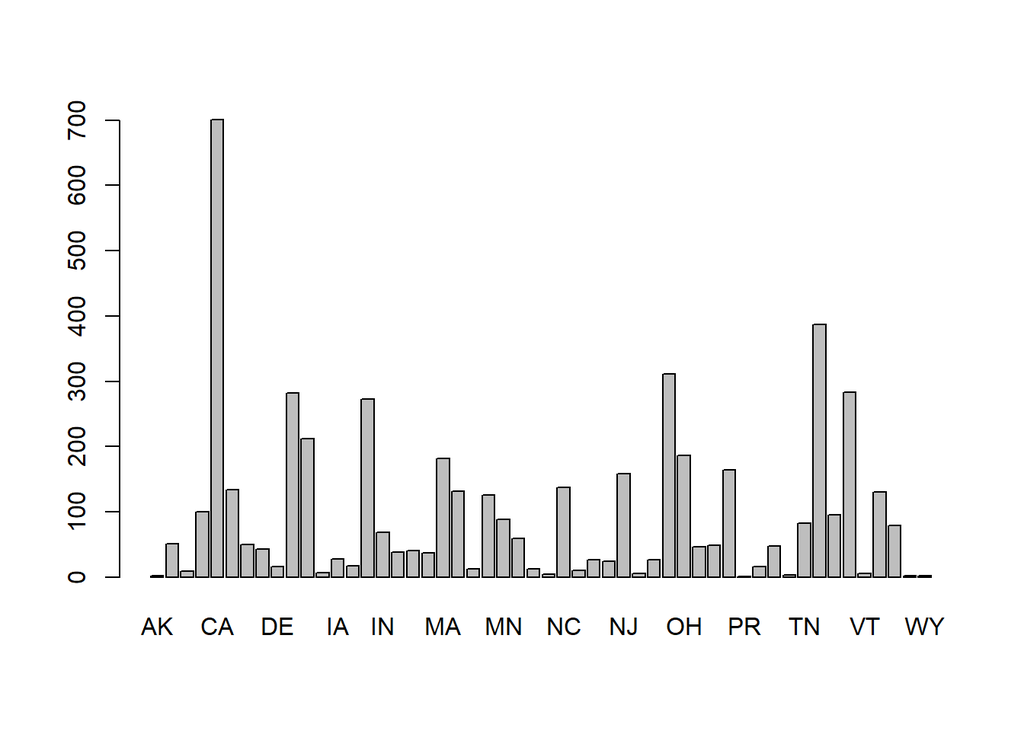

```r
plot(inc$State)
```

Initally, my first thought upon seeing this data was to use a map to display the data. Maps are very intuitive for people who are not familiar with data and are more visually interesting than a bar graph. However, a map of the United States would need to be displayed horizontally, which will not work for this particular problem. Also, small states like New Jersey, Rhode Island, and Maryland will be very hard to see on a small screen.

Given the accessibility problems with a map, there are a few things we can do to improve the original bar graph. To make the states more visible, we can flip the x and y axis so that states names will appear vertically. Given that we have more vertical space than horizontal space, it will be much easier to see the state names. The next problem is the distribution of the company counts by state. This problem was a little trickier to address and required a few additions to the graph. The first thing I did was sort the states by the number of companies instead of sorting by alphabetical order. Visually, it is much easier to distinguish the states with more companies from the states with fewer companies. I then added a color gradient that shifts from a darker blue to a lighter blue to further distinguish the states with differing numbers of companies.

While this layout was already significantly better than the original plot, I ran into another problem. Given that the graph is vertically long, it is not possible to see the x-axis markers and all the states without compressing the image. I decided to add the company count to the end of the bars to show exactly how many companies each state had, without having to look at the x-axis.

### Question 1 Answer

The resulting plot is shown below:

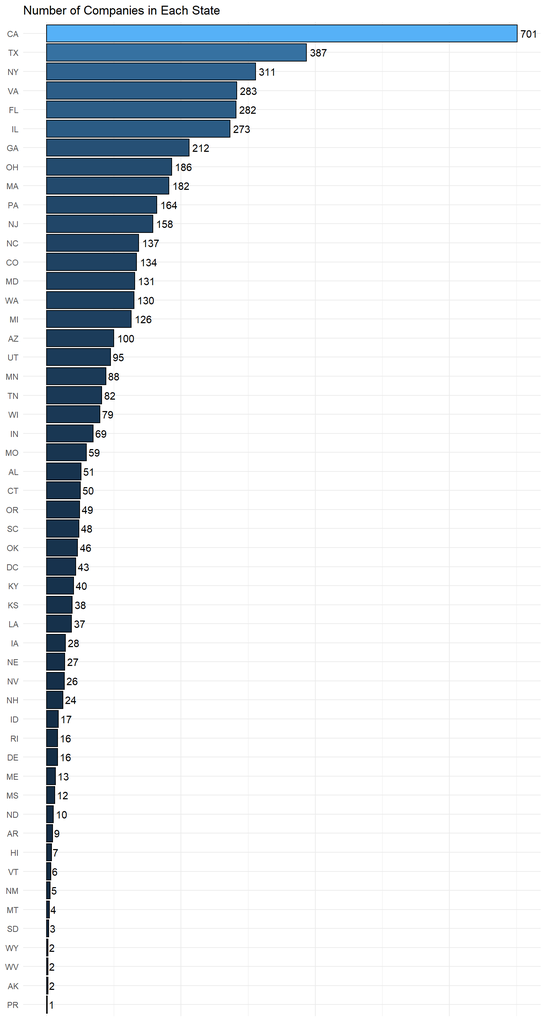

```r
# Answer Question 1 here

ggplot(inc, aes(x = factor(State, levels = names(sort(table(State),decreasing= F))))) + #sorts state counts in descending order
  geom_bar(aes(fill = ..count..), colour = "black") + #creates bar graph colored by number of companies
  coord_flip() + #flips x and y coordinates to make graph longer
  geom_text(stat = 'count', aes(label = ..count..), hjust = -0.2) + #adds number label to each bar
  ggtitle("Number of Companies in Each State") + #adds title
  guides(fill = F) + #removes legend
  theme_minimal() + #minimal theme for less intrusive visual elements
  theme(axis.title.x = element_blank(), #remove x-axis label
        axis.text.x = element_blank(), #remove x-axis text
        axis.ticks.x = element_blank(), #remove x-axis tick marks
        axis.title.y = element_blank()) #remove y-axis label
```

## Question 2

Lets dig in on the state with the 3rd most companies in the data set. Imagine you work for the state and are interested in how many people are employed by companies in different industries. Create a plot that shows the average and/or median employment by industry for companies in this state (only use cases with full data, use R’s `complete.cases()` function.) In addition to this, your graph should show how variable the ranges are, and you should deal with outliers.

### Data Prep

According to the graph from question 1, the state with the 3rd most companies is New York. In the code below, I used the `complete.cases` function to select the rows with complete cases. Afterwards, I selected the rows from New York as my new dataset.

```r
inc_complete = inc[complete.cases(inc),]
new_york = inc_complete[inc_complete$State == "NY",]
```

### Visualization Attempts

The first type of visualization I tried was the boxplot. The advantage of a boxplot is that it clearly shows the median as well as the spread of the data. Unfortunately, for this particular set of data, the ranges vary significantly by industry and it is hard to see each individual median. Also, the axes are not very informative.

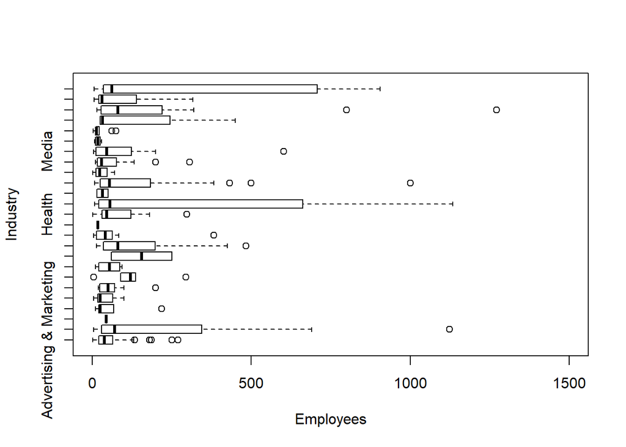

```r
boxplot(Employees~Industry, data = new_york, horizontal = T, ylim = c(0,1500))
```

My second attempt was to make a stacked density plot. Stacked density plots are nice because it allows the user to compare multiple distributions directly. However, when there are more than 3 distribution, stacked density plots become more difficult to distinguish from each other. Finding the median for each individual industry is even more difficult with this graph. It is possible to improve this graph by adding some interactable elements that lets the user select specific distributions to display, however, as a static image, the stacked density plot is not a good way to visualize this data.

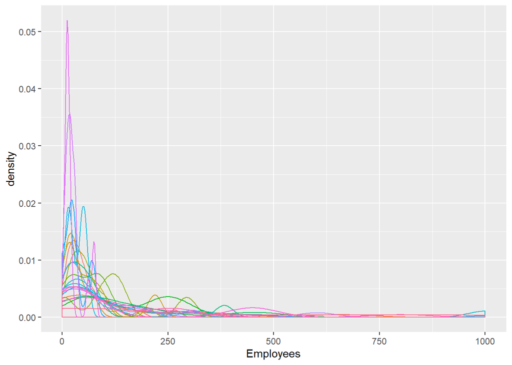

```r
ggplot(new_york, aes(x = Employees, color = Industry)) +
  geom_density() +
  #facet_wrap(~Industry) +
  theme(legend.position = "none") +
  xlim(0,1000)
```

### Question 2 Answer

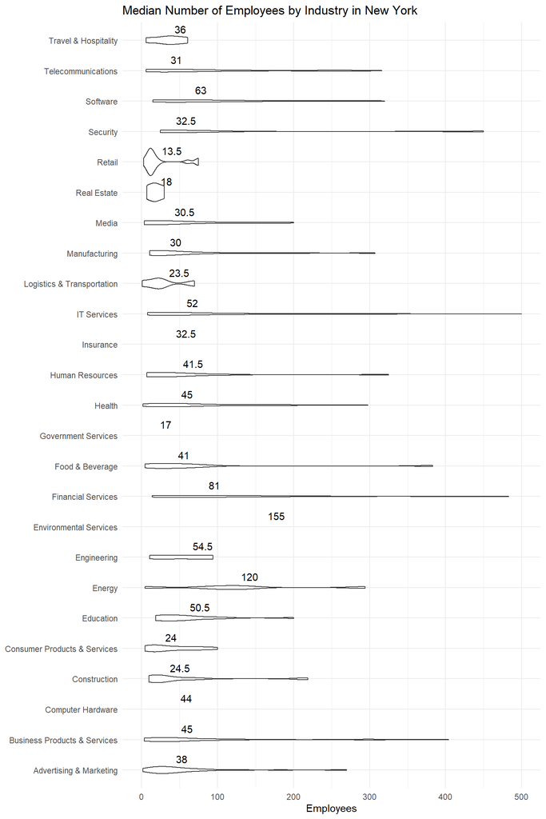

```r
# Answer Question 2 here

fun_median = function(x){ #function to show the median for each industry
  return(data.frame(y=median(x),label=median(x,na.rm=T)))
}


ggplot(new_york, aes(x = Industry, y = Employees)) + #adds data to violin plot
  geom_violin(trim = T) + #creates violin plot
  coord_flip() + #flips x and y axes
  ylim(0,500) + #limits x-axis to 500
  stat_summary(fun.data = fun_median, geom="text", vjust = -0.9, hjust = -0.5) + #adds median labels to plot
  theme_minimal() + #minimal theme to remove extraneous visual elements
  ggtitle("Median Number of Employees by Industry in New York") + #adds title
  theme(axis.title.y = element_blank()) #remove y-axis label
```

## Question 3

Now imagine you work for an investor and want to see which industries generate the most revenue per employee. Create a chart that makes this information clear. Once again, the distribution per industry should be shown.

### Data Prep

I added a variable to the complete data that takes the revenue of each company and divides it by the number of employees.

```r
inc_complete$Revenue_per_emp = inc_complete$Revenue/inc_complete$Employees
```

### Visualization Attempts

Like the previous problem, I wanted to see this data as a boxplot first. There were immediately problems. In addition to the problems specified in the previous question, this data has the issue of too many outliers. This boxplot is very cluttered and it is nearly impossible to tell which industry has the most revenue per employee.

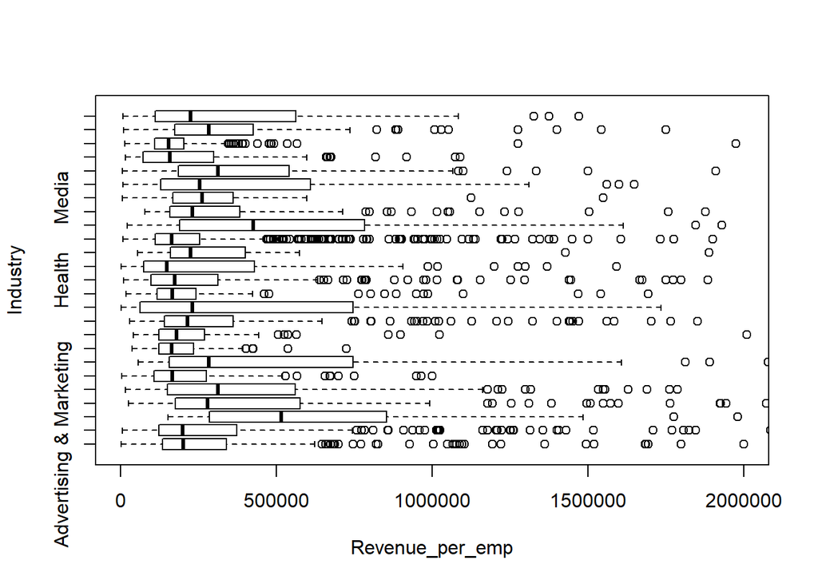

```r
boxplot(Revenue_per_emp~Industry, data = inc_complete, horizontal = T, ylim = c(0,2000000))
```

### Question 3 Solution

Violin plot again; hear me out. For the same reasons mentioned before, violin plots show the distribution much more clearly comapred to boxplots and are much more resistant to outliers. In the violin plot below, we can see the distribution of revenue per employee for each industry along with the maximum revenue per employee in each industry. In this case, the violin plot combines both the boxplot with the bar chart into a plot that shows the max values and distribution at the same time.

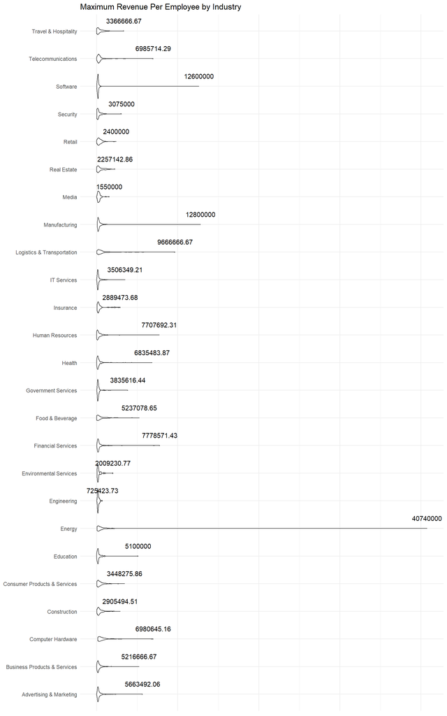

```r
# Answer Question 3 here

fun_max = function(x){
  return(data.frame(y=round(max(x),2),label=round(max(x,na.rm=T),2))) #function to display max value by industry
}

options(scipen = 1000) #removes scientific notation

ggplot(inc_complete, aes(x = Industry, y = Revenue_per_emp)) + #adds data
  geom_violin(trim = T) + #creates violin plot
  coord_flip() + #flips x and y axes
  theme_minimal() + #minimal theme removes extraneous visual elements
  ggtitle("Maximum Revenue Per Employee by Industry") + #add title
  theme(axis.title.y = element_blank(),
        axis.title.x = element_blank(),
        axis.ticks.x = element_blank(),
        axis.text.x = element_blank()) + #remove axis labels
  stat_summary(fun.data = fun_max, geom="text", vjust = -1.5, hjust = 0.5) #adds max value label
```